# linear model from Web

Seth Guzman

Read about the data from the website where it is staged. Then form three regression models; Model1 is SIMS~ARM, Model2 is SIMS~GRIP, and Model3 is SIMS~ARM+GRIP. For each model find a 95% prediction interval of SIMS given a value of 94 for GRIP and 88 for ARM. Compare Model1 with Model3 using anova. Write it up in a markdown document, push the project up to your github account and submit it back to canvas as link.

```r
data <- read.csv(file="https://onlinestatbook.com/case_studies_rvls/physical_strength/data.txt",sep="",header=TRUE)
```

## Model 1 SIM~ARMS

## Graphical Results

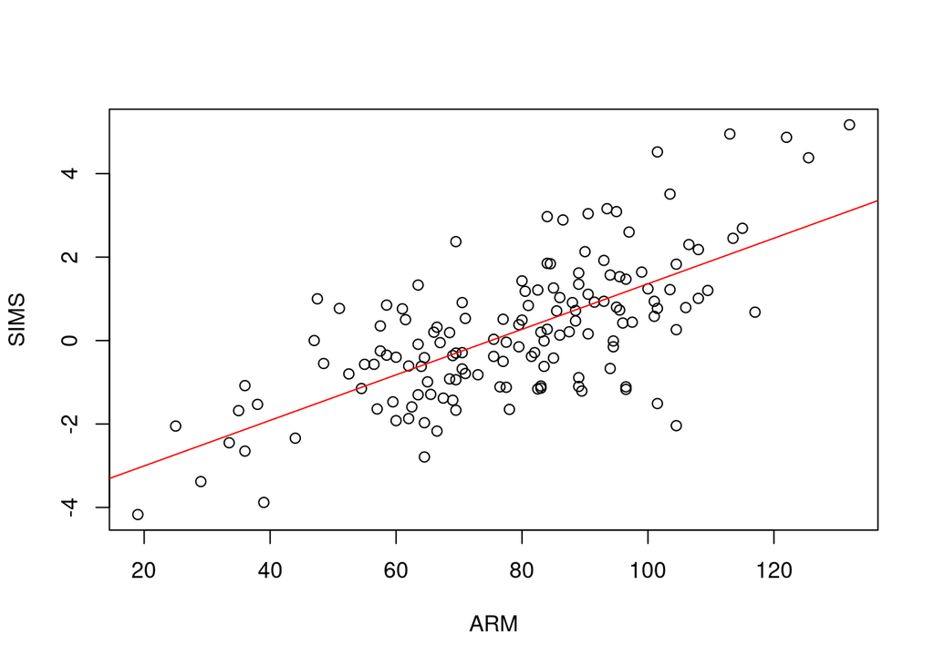

```r
model.1 <- lm(SIMS~ARM,data)
plot(SIMS~ARM,data=data)
abline(model.1, col='red')
```

ARM and SIMS both increase linearly with each other.

## Numerical Results

```r
cor(SIMS~ARM,data=data)
```

```
## [1] 0.6860073
```

The correlation is .68 proving that arm strength is related to sim score.

## Inferential results

```r
model.1 <- lm(SIMS~ARM,data)
summary.lm(model.1)
```

```
##
## Call:
## lm(formula = SIMS ~ ARM, data = data)
##
## Residuals:
##     Min      1Q  Median      3Q     Max
## -3.6467 -0.7502 -0.0285  0.6875  3.0770
##
## Coefficients:
##              Estimate Std. Error t value Pr(>|t|)
## (Intercept) -4.095160   0.391745  -10.45   <2e-16 ***
## ARM          0.054563   0.004806   11.35   <2e-16 ***
## ---
## Signif. codes:  0 '***' 0.001 '**' 0.01 '*' 0.05 '.' 0.1 ' ' 1
##
## Residual standard error: 1.226 on 145 degrees of freedom
## Multiple R-squared:  0.4706, Adjusted R-squared:  0.467
## F-statistic: 128.9 on 1 and 145 DF,  p-value: < 2.2e-16
```

both $b_0$ (intercept) and $b_1$ (coefficeient) of ARM strength are significant due to the small p value of both (<2e-16)

```r
newdata = data.frame(ARM=88, GRIP=94)
predict(model.1, newdata, interval="predict")
```

```
##         fit       lwr      upr
## 1 0.7063836 -1.726209 3.138977
```

the prediction interval is from -1.726209 to 3.138977 for SIMS score.

## Model 2 SIM~GRIP

### Now add in scatterplot

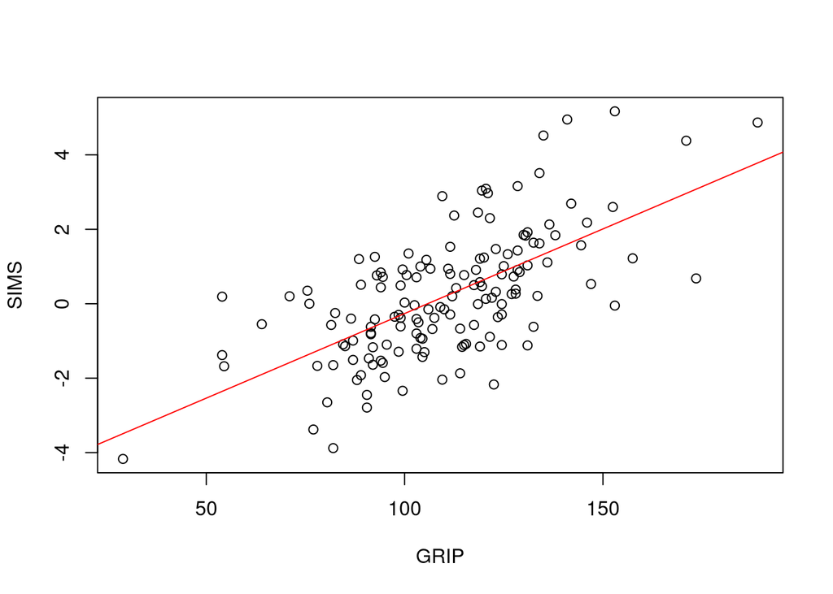

```r
model.2 <- lm(SIMS~GRIP,data)
plot(SIMS~GRIP,data=data)
abline(model.2, col='red')
```

As GRIP increases in value SIMS increases alongside it linearly as shown by the points

### Numerical results

```r
cor(SIMS~GRIP,data=data)
```

```
## [1] 0.6398458
```

SIMS and GRIP have a correlation of .63 proving they are linked together ### Inferential (Build model.2)

```r
model.2 <- lm(SIMS~GRIP,data)
summary.lm(model.2)
```

```
##
## Call:
## lm(formula = SIMS ~ GRIP, data = data)
##
## Residuals:
##     Min      1Q  Median      3Q     Max
## -2.9295 -0.8708 -0.1219  0.8039  3.3494
##
## Coefficients:
##              Estimate Std. Error t value Pr(>|t|)
## (Intercept) -4.809675   0.511141   -9.41   <2e-16 ***
## GRIP         0.045463   0.004535   10.03   <2e-16 ***
## ---
## Signif. codes:  0 '***' 0.001 '**' 0.01 '*' 0.05 '.' 0.1 ' ' 1
##
## Residual standard error: 1.295 on 145 degrees of freedom
## Multiple R-squared:  0.4094, Adjusted R-squared:  0.4053
## F-statistic: 100.5 on 1 and 145 DF,  p-value: < 2.2e-16
```

both $b_0$ (intercept) and $b_1$ (coefficeient) of GRIP strength are significant due to the small p value of both (<2e-16)

#### predict model.2 at target point

```r
newdata = data.frame(SIMS=88, GRIP=94)
predict(model.2, newdata, interval="predict")
```

```
##          fit       lwr      upr
## 1 -0.5361543 -3.107961 2.035652
```

## Model 3 SIM~ARM+GRIP

## Numerical results

```r
cor(SIMS~ARM+GRIP, data = data)
```

```
## [1] 0.7326545
```

The correlation is .73 proving ARM+GRIP is related to SIMS score. ## Inferential Results

```r
model.3 <- lm(SIMS~ARM+GRIP,data)
print(summary(model.3))
```

```
##
## Call:
## lm(formula = SIMS ~ ARM + GRIP, data = data)
##
## Residuals:
##     Min      1Q  Median      3Q     Max
## -3.1846 -0.7380 -0.0641  0.7394  2.8634
##
## Coefficients:
##              Estimate Std. Error t value Pr(>|t|)
## (Intercept) -5.433871   0.461815 -11.766  < 2e-16 ***
## ARM          0.037311   0.005774   6.462 1.50e-09 ***
## GRIP         0.024470   0.005158   4.744 4.99e-06 ***
## ---
## Signif. codes:  0 '***' 0.001 '**' 0.01 '*' 0.05 '.' 0.1 ' ' 1
##
## Residual standard error: 1.144 on 144 degrees of freedom
## Multiple R-squared:  0.5422, Adjusted R-squared:  0.5358
## F-statistic: 85.26 on 2 and 144 DF,  p-value: < 2.2e-16
```

ARM and GRIP are both closely related because both of there coefficient p value is extremely small.

## Prediction Interval

```r
newdata = data.frame(ARM= 88 , GRIP=94)
predict(model.3, newdata, interval = "predict")
```

```
##         fit       lwr      upr
## 1 0.1496476 -2.132373 2.431668
```

The prediction interval is from as low as -2.132373 to as high as 2.431668 for SIM score

## Comparing nested models ANOVA Test

### Model.1 vs Model.3

```r
anova(model.3,model.1)
```

```
## Analysis of Variance Table
##
## Model 1: SIMS ~ ARM + GRIP
## Model 2: SIMS ~ ARM
##   Res.Df    RSS Df Sum of Sq      F    Pr(>F)
## 1    144 188.43
## 2    145 217.88 -1    -29.45 22.506 4.994e-06 ***
## ---
## Signif. codes:  0 '***' 0.001 '**' 0.01 '*' 0.05 '.' 0.1 ' ' 1
```

i reject the null hypothesis because of how low the p value is (.0000049). model 1 is better then model 2 because of model 1 rss score being lower then model 2

### Model.2 vs Model.3

```r
anova(model.3,model.2)
```

```
## Analysis of Variance Table
##
## Model 1: SIMS ~ ARM + GRIP
## Model 2: SIMS ~ GRIP
##   Res.Df    RSS Df Sum of Sq      F    Pr(>F)
## 1    144 188.43
## 2    145 243.07 -1   -54.639 41.755 1.495e-09 ***
## ---
## Signif. codes:  0 '***' 0.001 '**' 0.01 '*' 0.05 '.' 0.1 ' ' 1
```

## Discussion and Conclusion

Through comparing models to each other ive found model 3 to be the best because it has a smalller rss score then all the models